# Survey Dashboard

2024 IOM South Sudan

Data & Methods Subteam - Bass Connections

2024-09-29

```r
#install packages

install.packages("sjmisc")
install.packages("likert")
```

All question numbers below are based on the “Key Variables for Descriptive Statistics” doc file.

All the descriptives calculated for index questions were based on the **unimputed** variable.

```r
#see all variables
#names(sudan_v2_df)

# Use grep to find column names
matching_columns <- grep("^Q10.13", names(sudan_v2_df), value = TRUE)

# Print the matching columns
matching_columns
```

```
## [1] "Q10.13_raw"       "Q10.13_unimputed" "Q10.13_imputed"
```

# 1) Political and Legal Fragility

All the answers are in a *scale of 0-1**, i.e. can have the following values: 0, 0.25, 0.5, 0.75, 1. The higher, the more fragile.

The higher, the more fragile.

## Index Questions

### Q10.1.2: How much confidence do you have in your state government?

#### Entire sample

| mean |
| --- |
| 0.51 |

| Response | Number of Responses | Percent of Total Responses |
| --- | --- | --- |
| Some confidence | 1440 | 0.39 |
| Confidence | 1323 | 0.36 |
| No confidence | 489 | 0.13 |
| A lot of confidence | 426 | 0.12 |
| Prefer not to answer | 7 | 0.00 |

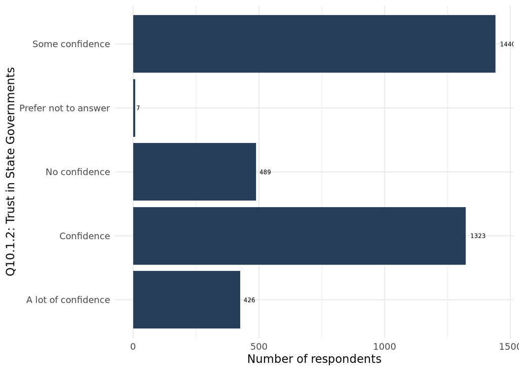

#### By county

| County | Mean Response (0 to 1) |
| --- | --- |
| Bor South | 0.65 |
| Kajo-keji | 0.32 |
| Lainya | 0.57 |
| Malakal | 0.55 |
| Morobo | 0.49 |
| Pibor | 0.40 |
| Rubkona | 0.53 |
| Wau | 0.46 |
| Yei | 0.63 |

| County | Response | Number of Responses | Percent of Total Responses |
| --- | --- | --- | --- |
| Yei | A lot of confidence | 15 | 0.04 |
| Yei | Confidence | 113 | 0.09 |
| Yei | No confidence | 93 | 0.19 |
| Yei | Some confidence | 189 | 0.13 |
| Wau | A lot of confidence | 48 | 0.11 |
| Wau | Confidence | 184 | 0.14 |
| Wau | No confidence | 28 | 0.06 |
| Wau | Prefer not to answer | 3 | 0.43 |
| Wau | Some confidence | 139 | 0.10 |
| Rubkona | A lot of confidence | 32 | 0.08 |
| Rubkona | Confidence | 117 | 0.09 |
| Rubkona | No confidence | 19 | 0.04 |
| Rubkona | Some confidence | 232 | 0.16 |
| Pibor | A lot of confidence | 82 | 0.19 |
| Pibor | Confidence | 193 | 0.15 |
| Pibor | No confidence | 36 | 0.07 |
| Pibor | Some confidence | 96 | 0.07 |
| Morobo | A lot of confidence | 72 | 0.17 |
| Morobo | Confidence | 128 | 0.10 |
| Morobo | No confidence | 64 | 0.13 |
| Morobo | Prefer not to answer | 1 | 0.14 |
| Morobo | Some confidence | 139 | 0.10 |
| Malakal | A lot of confidence | 5 | 0.01 |
| Malakal | Confidence | 168 | 0.13 |
| Malakal | No confidence | 33 | 0.07 |
| Malakal | Some confidence | 215 | 0.15 |
| Lainya | A lot of confidence | 23 | 0.05 |
| Lainya | Confidence | 136 | 0.10 |
| Lainya | No confidence | 60 | 0.12 |
| Lainya | Prefer not to answer | 2 | 0.29 |
| Lainya | Some confidence | 193 | 0.13 |
| Kajo-keji | A lot of confidence | 130 | 0.31 |
| Kajo-keji | Confidence | 169 | 0.13 |
| Kajo-keji | No confidence | 23 | 0.05 |
| Kajo-keji | Prefer not to answer | 1 | 0.14 |
| Kajo-keji | Some confidence | 75 | 0.05 |
| Bor South | A lot of confidence | 19 | 0.04 |
| Bor South | Confidence | 115 | 0.09 |
| Bor South | No confidence | 133 | 0.27 |
| Bor South | Some confidence | 162 | 0.11 |

### Q10.1.10: How much confidence do you have in informal authorities, such as councils of elders?

#### Entire sample

| mean |
| --- |
| 0.45 |

| Response | Number of Responses | Percent of Total Responses |
| --- | --- | --- |
| Confidence | 1524 | 0.41 |
| Some confidence | 1215 | 0.33 |
| A lot of confidence | 605 | 0.16 |
| No confidence | 316 | 0.09 |
| Prefer not to answer | 25 | 0.01 |

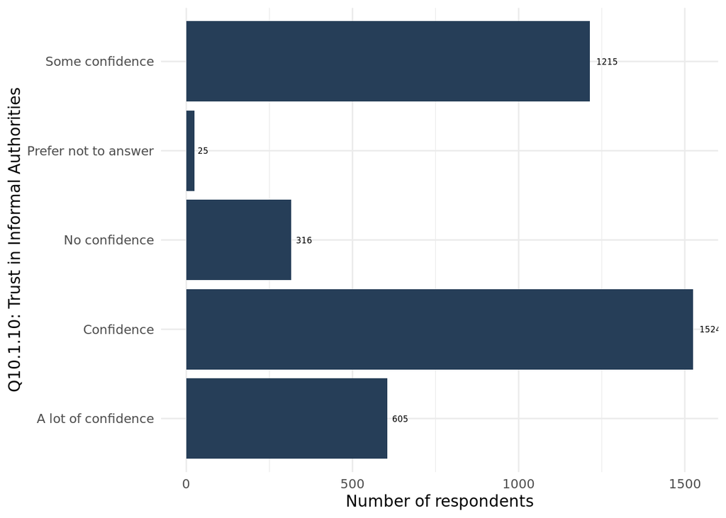

#### By county

| County | Mean Response (0 to 1) |
| --- | --- |
| Bor South | 0.34 |
| Kajo-keji | 0.36 |
| Lainya | 0.45 |
| Malakal | 0.45 |
| Morobo | 0.41 |
| Pibor | 0.49 |
| Rubkona | 0.50 |
| Wau | 0.46 |
| Yei | 0.56 |

| County | Response | Number of Responses | Percent of Total Responses |
| --- | --- | --- | --- |
| Yei | A lot of confidence | 23 | 0.04 |
| Yei | Confidence | 139 | 0.09 |
| Yei | No confidence | 55 | 0.17 |
| Yei | Some confidence | 193 | 0.16 |
| Wau | A lot of confidence | 57 | 0.09 |
| Wau | Confidence | 150 | 0.10 |
| Wau | No confidence | 16 | 0.05 |
| Wau | Prefer not to answer | 9 | 0.36 |
| Wau | Some confidence | 170 | 0.14 |
| Rubkona | A lot of confidence | 34 | 0.06 |
| Rubkona | Confidence | 139 | 0.09 |
| Rubkona | No confidence | 6 | 0.02 |
| Rubkona | Prefer not to answer | 1 | 0.04 |
| Rubkona | Some confidence | 220 | 0.18 |
| Pibor | A lot of confidence | 52 | 0.09 |
| Pibor | Confidence | 182 | 0.12 |
| Pibor | No confidence | 73 | 0.23 |
| Pibor | Prefer not to answer | 1 | 0.04 |
| Pibor | Some confidence | 99 | 0.08 |
| Morobo | A lot of confidence | 74 | 0.12 |
| Morobo | Confidence | 194 | 0.13 |
| Morobo | No confidence | 35 | 0.11 |
| Morobo | Prefer not to answer | 2 | 0.08 |
| Morobo | Some confidence | 99 | 0.08 |
| Malakal | A lot of confidence | 16 | 0.03 |
| Malakal | Confidence | 250 | 0.16 |
| Malakal | No confidence | 6 | 0.02 |
| Malakal | Some confidence | 149 | 0.12 |
| Lainya | A lot of confidence | 91 | 0.15 |
| Lainya | Confidence | 145 | 0.10 |
| Lainya | No confidence | 57 | 0.18 |
| Lainya | Prefer not to answer | 5 | 0.20 |
| Lainya | Some confidence | 116 | 0.10 |
| Kajo-keji | A lot of confidence | 94 | 0.16 |
| Kajo-keji | Confidence | 188 | 0.12 |
| Kajo-keji | No confidence | 19 | 0.06 |
| Kajo-keji | Prefer not to answer | 7 | 0.28 |
| Kajo-keji | Some confidence | 90 | 0.07 |
| Bor South | A lot of confidence | 164 | 0.27 |
| Bor South | Confidence | 137 | 0.09 |
| Bor South | No confidence | 49 | 0.16 |
| Bor South | Some confidence | 79 | 0.07 |

### Q10.10: South Sudan’s next national elections are scheduled for December 2024 after being postponed several times. How safe or unsafe would you feel going to a polling station to cast your vote?

#### Entire sample

| mean |
| --- |
| 0.5 |

| Response | Number of Responses | Percent of Total Responses |
| --- | --- | --- |
| Very unsafe | 820 | 0.22 |
| Very safe | 802 | 0.22 |
| Somewhat safe | 695 | 0.19 |
| Neither safe nor unsafe | 677 | 0.18 |
| Somewhat unsafe | 621 | 0.17 |
| Prefer not to answer | 70 | 0.02 |

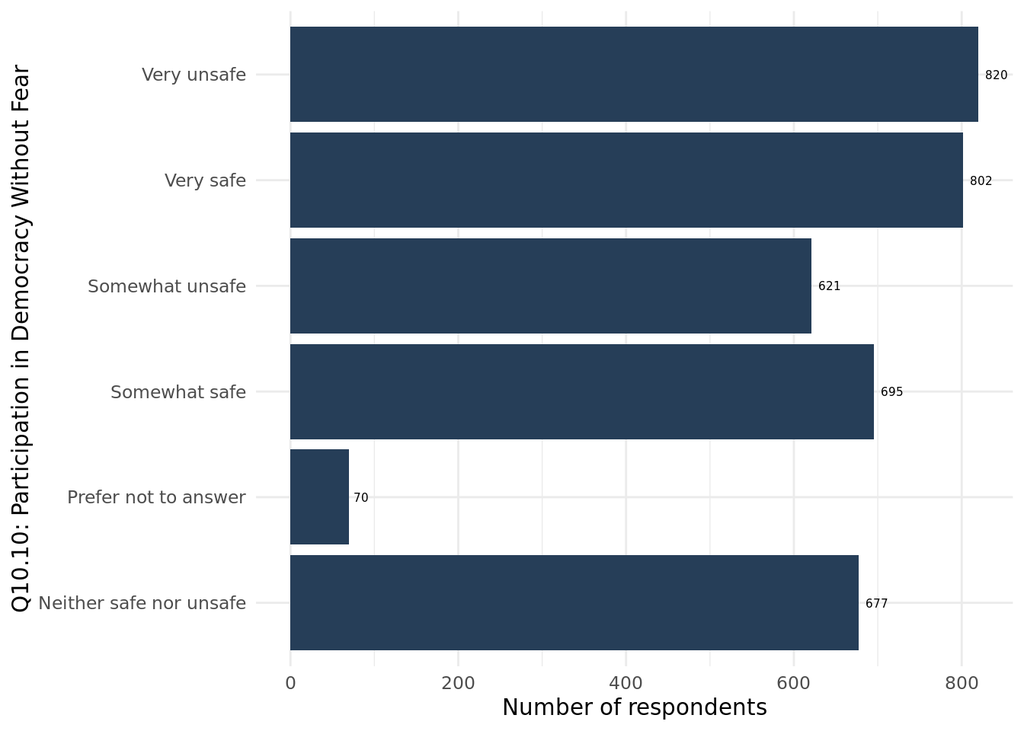

#### By county

| County | Mean Response (0 to 1) |
| --- | --- |
| Bor South | 0.58 |
| Kajo-keji | 0.43 |
| Lainya | 0.52 |
| Malakal | 0.55 |
| Morobo | 0.29 |
| Pibor | 0.60 |
| Rubkona | 0.68 |
| Wau | 0.40 |
| Yei | 0.41 |

| County | Response | Number of Responses | Percent of Total Responses |
| --- | --- | --- | --- |
| Yei | Neither safe nor unsafe | 89 | 0.13 |
| Yei | Prefer not to answer | 3 | 0.04 |
| Yei | Somewhat safe | 132 | 0.19 |
| Yei | Somewhat unsafe | 66 | 0.11 |
| Yei | Very safe | 81 | 0.10 |
| Yei | Very unsafe | 39 | 0.05 |
| Wau | Neither safe nor unsafe | 105 | 0.16 |
| Wau | Prefer not to answer | 38 | 0.54 |
| Wau | Somewhat safe | 107 | 0.15 |
| Wau | Somewhat unsafe | 57 | 0.09 |
| Wau | Very safe | 73 | 0.09 |
| Wau | Very unsafe | 22 | 0.03 |
| Rubkona | Neither safe nor unsafe | 48 | 0.07 |
| Rubkona | Prefer not to answer | 4 | 0.06 |
| Rubkona | Somewhat safe | 56 | 0.08 |
| Rubkona | Somewhat unsafe | 84 | 0.14 |
| Rubkona | Very safe | 38 | 0.05 |
| Rubkona | Very unsafe | 170 | 0.21 |
| Pibor | Neither safe nor unsafe | 85 | 0.13 |
| Pibor | Prefer not to answer | 6 | 0.09 |
| Pibor | Somewhat safe | 60 | 0.09 |
| Pibor | Somewhat unsafe | 137 | 0.22 |
| Pibor | Very safe | 40 | 0.05 |
| Pibor | Very unsafe | 79 | 0.10 |
| Morobo | Neither safe nor unsafe | 43 | 0.06 |
| Morobo | Somewhat safe | 52 | 0.07 |
| Morobo | Somewhat unsafe | 42 | 0.07 |
| Morobo | Very safe | 215 | 0.27 |
| Morobo | Very unsafe | 52 | 0.06 |
| Malakal | Neither safe nor unsafe | 75 | 0.11 |
| Malakal | Prefer not to answer | 2 | 0.03 |
| Malakal | Somewhat safe | 150 | 0.22 |
| Malakal | Somewhat unsafe | 69 | 0.11 |
| Malakal | Very safe | 21 | 0.03 |
| Malakal | Very unsafe | 104 | 0.13 |
| Lainya | Neither safe nor unsafe | 88 | 0.13 |
| Lainya | Prefer not to answer | 8 | 0.11 |
| Lainya | Somewhat safe | 43 | 0.06 |
| Lainya | Somewhat unsafe | 50 | 0.08 |
| Lainya | Very safe | 105 | 0.13 |
| Lainya | Very unsafe | 120 | 0.15 |
| Kajo-keji | Neither safe nor unsafe | 48 | 0.07 |
| Kajo-keji | Prefer not to answer | 5 | 0.07 |
| Kajo-keji | Somewhat safe | 66 | 0.09 |
| Kajo-keji | Somewhat unsafe | 45 | 0.07 |
| Kajo-keji | Very safe | 140 | 0.17 |
| Kajo-keji | Very unsafe | 94 | 0.11 |
| Bor South | Neither safe nor unsafe | 96 | 0.14 |
| Bor South | Prefer not to answer | 4 | 0.06 |
| Bor South | Somewhat safe | 29 | 0.04 |
| Bor South | Somewhat unsafe | 71 | 0.11 |
| Bor South | Very safe | 89 | 0.11 |
| Bor South | Very unsafe | 140 | 0.17 |

### Q10.12: At present, how safe do you feel speaking publicly on politically sensitive issues?

#### Entire sample

| mean |
| --- |
| 0.6 |

| Response | Number of Responses | Percent of Total Responses |
| --- | --- | --- |
| Unsafe | 1093 | 0.30 |
| Very unsafe | 833 | 0.23 |
| Safe | 810 | 0.22 |
| Neither safe nor unsafe | 641 | 0.17 |
| Very safe | 238 | 0.06 |
| Prefer not to answer | 70 | 0.02 |

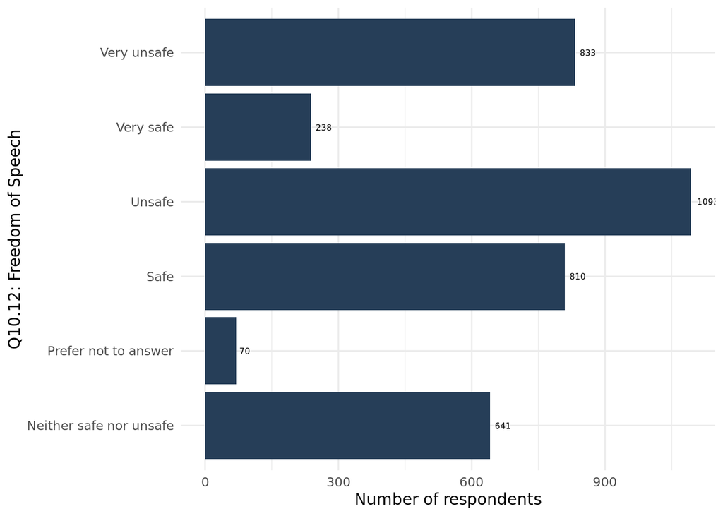

#### By county

| County | Mean Response (0 to 1) |
| --- | --- |
| Bor South | 0.69 |
| Kajo-keji | 0.65 |
| Lainya | 0.57 |
| Malakal | 0.61 |
| Morobo | 0.56 |
| Pibor | 0.54 |
| Rubkona | 0.71 |
| Wau | 0.57 |
| Yei | 0.53 |

| County | Response | Number of Responses | Percent of Total Responses |
| --- | --- | --- | --- |
| Yei | Neither safe nor unsafe | 103 | 0.16 |
| Yei | Prefer not to answer | 5 | 0.07 |
| Yei | Safe | 117 | 0.14 |
| Yei | Unsafe | 151 | 0.14 |
| Yei | Very safe | 12 | 0.05 |
| Yei | Very unsafe | 22 | 0.03 |
| Wau | Neither safe nor unsafe | 78 | 0.12 |
| Wau | Prefer not to answer | 44 | 0.63 |
| Wau | Safe | 79 | 0.10 |
| Wau | Unsafe | 139 | 0.13 |
| Wau | Very safe | 22 | 0.09 |
| Wau | Very unsafe | 40 | 0.05 |
| Rubkona | Neither safe nor unsafe | 40 | 0.06 |
| Rubkona | Prefer not to answer | 2 | 0.03 |
| Rubkona | Safe | 56 | 0.07 |
| Rubkona | Unsafe | 89 | 0.08 |
| Rubkona | Very safe | 33 | 0.14 |
| Rubkona | Very unsafe | 180 | 0.22 |
| Pibor | Neither safe nor unsafe | 110 | 0.17 |
| Pibor | Prefer not to answer | 7 | 0.10 |
| Pibor | Safe | 115 | 0.14 |
| Pibor | Unsafe | 140 | 0.13 |
| Pibor | Very safe | 8 | 0.03 |
| Pibor | Very unsafe | 27 | 0.03 |
| Morobo | Neither safe nor unsafe | 40 | 0.06 |
| Morobo | Prefer not to answer | 1 | 0.01 |
| Morobo | Safe | 127 | 0.16 |
| Morobo | Unsafe | 75 | 0.07 |
| Morobo | Very safe | 45 | 0.19 |
| Morobo | Very unsafe | 116 | 0.14 |
| Malakal | Neither safe nor unsafe | 73 | 0.11 |
| Malakal | Safe | 103 | 0.13 |
| Malakal | Unsafe | 175 | 0.16 |
| Malakal | Very safe | 8 | 0.03 |
| Malakal | Very unsafe | 62 | 0.07 |
| Lainya | Neither safe nor unsafe | 87 | 0.14 |
| Lainya | Prefer not to answer | 4 | 0.06 |
| Lainya | Safe | 89 | 0.11 |
| Lainya | Unsafe | 123 | 0.11 |
| Lainya | Very safe | 37 | 0.16 |
| Lainya | Very unsafe | 74 | 0.09 |
| Kajo-keji | Neither safe nor unsafe | 45 | 0.07 |
| Kajo-keji | Prefer not to answer | 5 | 0.07 |
| Kajo-keji | Safe | 69 | 0.09 |
| Kajo-keji | Unsafe | 61 | 0.06 |
| Kajo-keji | Very safe | 49 | 0.21 |
| Kajo-keji | Very unsafe | 169 | 0.20 |
| Bor South | Neither safe nor unsafe | 65 | 0.10 |
| Bor South | Prefer not to answer | 2 | 0.03 |
| Bor South | Safe | 55 | 0.07 |
| Bor South | Unsafe | 140 | 0.13 |
| Bor South | Very safe | 24 | 0.10 |
| Bor South | Very unsafe | 143 | 0.17 |

### Q10.13: Which of the following statements best describes the role that politicians in Juba play in your community?

#### Entire sample

| mean |
| --- |
| 0.67 |

| Response | Number of Responses | Percent of Total Responses |
| --- | --- | --- |
| Politicians in Juba make this community much less safe | 1043 | 0.28 |
| Politicians in Juba make this community less safe | 943 | 0.26 |
| Politicians in Juba neither make this community more nor less safe | 867 | 0.24 |
| Politicians in Juba make this community more safe | 404 | 0.11 |
| Prefer not to answer | 283 | 0.08 |
| Politicians in Juba make this community much more safe | 145 | 0.04 |

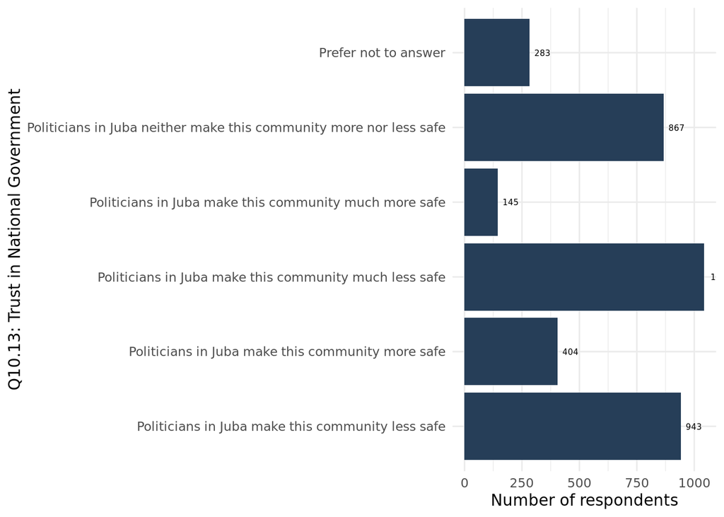

#### By county

| County | Mean Response (0 to 1) |
| --- | --- |
| Bor South | 0.76 |
| Kajo-keji | 0.56 |
| Lainya | 0.58 |
| Malakal | 0.74 |
| Morobo | 0.61 |
| Pibor | 0.67 |
| Rubkona | 0.76 |
| Wau | 0.54 |
| Yei | 0.75 |

| County | Response | Number of Responses | Percent of Total Responses |
| --- | --- | --- | --- |
| Yei | Politicians in Juba make this community less safe | 151 | 0.16 |
| Yei | Politicians in Juba make this community more safe | 23 | 0.06 |
| Yei | Politicians in Juba make this community much less safe | 145 | 0.14 |
| Yei | Politicians in Juba make this community much more safe | 7 | 0.05 |
| Yei | Politicians in Juba neither make this community more nor less safe | 78 | 0.09 |
| Yei | Prefer not to answer | 6 | 0.02 |
| Wau | Politicians in Juba make this community less safe | 65 | 0.07 |
| Wau | Politicians in Juba make this community more safe | 43 | 0.11 |
| Wau | Politicians in Juba make this community much less safe | 35 | 0.03 |
| Wau | Politicians in Juba make this community much more safe | 28 | 0.19 |
| Wau | Politicians in Juba neither make this community more nor less safe | 70 | 0.08 |
| Wau | Prefer not to answer | 161 | 0.57 |
| Rubkona | Politicians in Juba make this community less safe | 83 | 0.09 |
| Rubkona | Politicians in Juba make this community more safe | 26 | 0.06 |
| Rubkona | Politicians in Juba make this community much less safe | 182 | 0.17 |
| Rubkona | Politicians in Juba make this community much more safe | 4 | 0.03 |
| Rubkona | Politicians in Juba neither make this community more nor less safe | 100 | 0.12 |
| Rubkona | Prefer not to answer | 5 | 0.02 |
| Pibor | Politicians in Juba make this community less safe | 111 | 0.12 |
| Pibor | Politicians in Juba make this community more safe | 54 | 0.13 |
| Pibor | Politicians in Juba make this community much less safe | 126 | 0.12 |
| Pibor | Politicians in Juba make this community much more safe | 17 | 0.12 |
| Pibor | Politicians in Juba neither make this community more nor less safe | 91 | 0.10 |
| Pibor | Prefer not to answer | 8 | 0.03 |
| Morobo | Politicians in Juba make this community less safe | 93 | 0.10 |
| Morobo | Politicians in Juba make this community more safe | 55 | 0.14 |
| Morobo | Politicians in Juba make this community much less safe | 113 | 0.11 |
| Morobo | Politicians in Juba make this community much more safe | 46 | 0.32 |
| Morobo | Politicians in Juba neither make this community more nor less safe | 96 | 0.11 |
| Morobo | Prefer not to answer | 1 | 0.00 |
| Malakal | Politicians in Juba make this community less safe | 197 | 0.21 |
| Malakal | Politicians in Juba make this community more safe | 20 | 0.05 |
| Malakal | Politicians in Juba make this community much less safe | 117 | 0.11 |
| Malakal | Politicians in Juba neither make this community more nor less safe | 87 | 0.10 |
| Lainya | Politicians in Juba make this community less safe | 97 | 0.10 |
| Lainya | Politicians in Juba make this community more safe | 56 | 0.14 |
| Lainya | Politicians in Juba make this community much less safe | 68 | 0.07 |
| Lainya | Politicians in Juba make this community much more safe | 23 | 0.16 |
| Lainya | Politicians in Juba neither make this community more nor less safe | 155 | 0.18 |
| Lainya | Prefer not to answer | 15 | 0.05 |
| Kajo-keji | Politicians in Juba make this community less safe | 65 | 0.07 |
| Kajo-keji | Politicians in Juba make this community more safe | 110 | 0.27 |
| Kajo-keji | Politicians in Juba make this community much less safe | 83 | 0.08 |
| Kajo-keji | Politicians in Juba make this community much more safe | 14 | 0.10 |
| Kajo-keji | Politicians in Juba neither make this community more nor less safe | 89 | 0.10 |
| Kajo-keji | Prefer not to answer | 37 | 0.13 |
| Bor South | Politicians in Juba make this community less safe | 81 | 0.09 |
| Bor South | Politicians in Juba make this community more safe | 17 | 0.04 |
| Bor South | Politicians in Juba make this community much less safe | 174 | 0.17 |
| Bor South | Politicians in Juba make this community much more safe | 6 | 0.04 |
| Bor South | Politicians in Juba neither make this community more nor less safe | 101 | 0.12 |
| Bor South | Prefer not to answer | 50 | 0.18 |

# Additional Political/Legal Descriptive Questions

### Q9.1 **Imagine that you have a problem or a dispute, who would you first seek help from? (Do NOT read the answers)**

### Q9.2 **Do you feel that you are able to resolve any disputes you have with community members without experiencing discrimination?**

### Q9.3 **Imagine that a person from this community stole cattle from your family. Who would you be most likely to seek help from?**

### Q9.4 I**magine that a person from outside this community stole cattle from your family. Who would you be most likely to seek help from?**

### Q9.5 **Q9.5 Imagine that there is an outbreak of violent clashes between two different ethnic groups in your area. Which actor would be most helpful for resolving this dispute?**

### Q10.1.1 How much confidence do you have in your local government?

### Q10.1.3 How much confidence do you have in the national government?

### Q10.1.4 How much confidence do you have in the police?

### Q10.1.5 How much confidence do you have in the military

### Q10.1.6 How much confidence do you have in the statutory courts?

### Q10.1.7 How much confidence do you have in religious institutions/leaders?

### Q10.1.8 How much confidence do you have in customary law?

### Q10.1.9 How much confidence do you have in village chiefs?